# Objective

1.Explore and visualize the dataset.  
2.Build a linear regression model to predict the prices of used cars.  
3.Generate a set of insights and recommendations that will help the business.

# Data Dictionary

S.No. : Serial Number  
Name : Name of the car which includes Brand name and Model name  
Location : The location in which the car is being sold or is available for purchase Cities  
Year : Manufacturing year of the car  
Kilometers_driven : The total kilometers driven in the car by the previous owner(s) in KM.  
Fuel_Type : The type of fuel used by the car. (Petrol, Diesel, Electric, CNG, LPG)  
Transmission : The type of transmission used by the car. (Automatic / Manual)  
Owner : Type of ownership  
Mileage : The standard mileage offered by the car company in kmpl or km/kg  
Engine : The displacement volume of the engine in CC.  
Power : The maximum power of the engine in bhp.  
Seats : The number of seats in the car.  
New_Price : The price of a new car of the same model in INR Lakhs.(1 Lakh = 100, 000)  
Price : The price of the used car in INR Lakhs (1 Lakh = 100, 000)

# Loading libraries

```python
import numpy as np
from sklearn.linear_model import LinearRegression
import pandas as pd
import matplotlib.pyplot as plt
%matplotlib inline
import seaborn as sns
from sklearn.model_selection import train_test_split
import warnings
warnings.filterwarnings('ignore')
from statsmodels.stats.outliers_influence import variance_inflation_factor
from sklearn import linear_model
from sklearn.metrics import mean_squared_error, r2_score
from sklearn import preprocessing
```

# Loading and exploring the data

```python
df = pd.read_csv("used_cars_data.csv", index_col=0)
print(f'There are {df.shape[0]} rows and {df.shape[1]} columns.')
np.random.seed(1)
df.sample(n=10)
```

```
There are 7253 rows and 13 columns.
```

| S.No. | Name | Location | Year | Kilometers_Driven | Fuel_Type | Transmission | Owner_Type | Mileage | Engine | Power | Seats | New_Price | Price |
| --- | --- | --- | --- | --- | --- | --- | --- | --- | --- | --- | --- | --- | --- |
| 2397 | Ford EcoSport 1.5 Petrol Trend | Kolkata | 2016 | 21460 | Petrol | Manual | First | 17.0 kmpl | 1497 CC | 121.36 bhp | 5.0 | 9.47 Lakh | 6.00 |
| 3777 | Maruti Wagon R VXI 1.2 | Kochi | 2015 | 49818 | Petrol | Manual | First | 21.5 kmpl | 1197 CC | 81.80 bhp | 5.0 | 5.44 Lakh | 4.11 |
| 4425 | Ford Endeavour 4x2 XLT | Hyderabad | 2007 | 130000 | Diesel | Manual | First | 13.1 kmpl | 2499 CC | 141 bhp | 7.0 | NaN | 6.00 |
| 3661 | Mercedes-Benz E-Class E250 CDI Avantgrade | Coimbatore | 2016 | 39753 | Diesel | Automatic | First | 13.0 kmpl | 2143 CC | 201.1 bhp | 5.0 | NaN | 35.28 |
| 4514 | Hyundai Xcent 1.2 Kappa AT SX Option | Kochi | 2016 | 45560 | Petrol | Automatic | First | 16.9 kmpl | 1197 CC | 82 bhp | 5.0 | NaN | 6.34 |
| 599 | Toyota Innova Crysta 2.8 ZX AT | Coimbatore | 2019 | 40674 | Diesel | Automatic | First | 11.36 kmpl | 2755 CC | 171.5 bhp | 7.0 | 28.05 Lakh | 24.82 |
| 186 | Mercedes-Benz E-Class E250 CDI Avantgrade | Bangalore | 2014 | 37382 | Diesel | Automatic | First | 13.0 kmpl | 2143 CC | 201.1 bhp | 5.0 | NaN | 32.00 |
| 305 | Audi A6 2011-2015 2.0 TDI Premium Plus | Kochi | 2014 | 61726 | Diesel | Automatic | First | 17.68 kmpl | 1968 CC | 174.33 bhp | 5.0 | NaN | 20.77 |
| 4582 | Hyundai i20 1.2 Magna | Kolkata | 2011 | 36000 | Petrol | Manual | First | 18.5 kmpl | 1197 CC | 80 bhp | 5.0 | NaN | 2.50 |
| 5434 | Honda WR-V Edge Edition i-VTEC S | Kochi | 2019 | 13913 | Petrol | Manual | First | 17.5 kmpl | 1199 CC | 88.7 bhp | 5.0 | 9.36 Lakh | 8.20 |

# View the first 5 rows of the dataset

```python
df.head(5)
```

| S.No. | Name | Location | Year | Kilometers_Driven | Fuel_Type | Transmission | Owner_Type | Mileage | Engine | Power | Seats | New_Price | Price |
| --- | --- | --- | --- | --- | --- | --- | --- | --- | --- | --- | --- | --- | --- |
| 0 | Maruti Wagon R LXI CNG | Mumbai | 2010 | 72000 | CNG | Manual | First | 26.6 km/kg | 998 CC | 58.16 bhp | 5.0 | NaN | 1.75 |
| 1 | Hyundai Creta 1.6 CRDi SX Option | Pune | 2015 | 41000 | Diesel | Manual | First | 19.67 kmpl | 1582 CC | 126.2 bhp | 5.0 | NaN | 12.50 |
| 2 | Honda Jazz V | Chennai | 2011 | 46000 | Petrol | Manual | First | 18.2 kmpl | 1199 CC | 88.7 bhp | 5.0 | 8.61 Lakh | 4.50 |
| 3 | Maruti Ertiga VDI | Chennai | 2012 | 87000 | Diesel | Manual | First | 20.77 kmpl | 1248 CC | 88.76 bhp | 7.0 | NaN | 6.00 |
| 4 | Audi A4 New 2.0 TDI Multitronic | Coimbatore | 2013 | 40670 | Diesel | Automatic | Second | 15.2 kmpl | 1968 CC | 140.8 bhp | 5.0 | NaN | 17.74 |

# From the Name extract the brand name

```python
df.Name.unique()
```

```
array(['Maruti Wagon R LXI CNG', 'Hyundai Creta 1.6 CRDi SX Option',
       'Honda Jazz V', ..., 'Ford EcoSport 1.5 Petrol Ambiente',
       'Jeep Compass 1.4 Sport', 'Hyundai Elite i20 Magna Plus'],
      dtype=object)
```

```python
df["brand"]=""
df["age"]=0
```

# Find car's age

```python
for i in df.index:
    name = df["Name"][i]
    name2 = name.split(' ', 1)[0]
    df["brand"][i]=name2
    df["Name"][i]=name.replace(name2,"")
    df["age"][i]=(2021-df["Year"][i])
```

```python
df.brand.unique()
```

```
array(['Maruti', 'Hyundai', 'Honda', 'Audi', 'Nissan', 'Toyota',
       'Volkswagen', 'Tata', 'Land', 'Mitsubishi', 'Renault',
       'Mercedes-Benz', 'BMW', 'Mahindra', 'Ford', 'Porsche', 'Datsun',
       'Jaguar', 'Volvo', 'Chevrolet', 'Skoda', 'Mini', 'Fiat', 'Jeep',
       'Smart', 'Ambassador', 'Isuzu', 'ISUZU', 'Force', 'Bentley',
       'Lamborghini', 'Hindustan', 'OpelCorsa'], dtype=object)
```

```python
df["brand"]
```

```
S.No.
0              Maruti
1             Hyundai
2               Honda
3              Maruti
4                Audi
            ...
7248       Volkswagen
7249       Volkswagen
7250           Nissan
7251       Volkswagen
7252    Mercedes-Benz
Name: brand, Length: 7253, dtype: object
```

# Location

```python
df.Location.unique()
```

```
array(['Mumbai', 'Pune', 'Chennai', 'Coimbatore', 'Hyderabad', 'Jaipur',
       'Kochi', 'Kolkata', 'Delhi', 'Bangalore', 'Ahmedabad'],
      dtype=object)
```

# Fuel type

```python
df.Fuel_Type.unique()
```

```
array(['CNG', 'Diesel', 'Petrol', 'LPG', 'Electric'], dtype=object)
```

# Type of car

```python
df.Transmission.unique()
```

```
array(['Manual', 'Automatic'], dtype=object)
```

# Encode the Name variable

```python
le = preprocessing.LabelEncoder()
le.fit(df['Name'])
df['Name'] = le.transform(df['Name'])
```

# About data type and null values

```python
df.info()
```

```
<class 'pandas.core.frame.DataFrame'>
Int64Index: 7253 entries, 0 to 7252
Data columns (total 15 columns):
 #   Column             Non-Null Count  Dtype
---  ------             --------------  -----
 0   Name               7253 non-null   int64
 1   Location           7253 non-null   object
 2   Year               7253 non-null   int64
 3   Kilometers_Driven  7253 non-null   int64
 4   Fuel_Type          7253 non-null   object
 5   Transmission       7253 non-null   object
 6   Owner_Type         7253 non-null   object
 7   Mileage            7251 non-null   object
 8   Engine             7207 non-null   object
 9   Power              7207 non-null   object
 10  Seats              7200 non-null   float64
 11  New_Price          1006 non-null   object
 12  Price              6019 non-null   float64
 13  brand              7253 non-null   object
 14  age                7253 non-null   int64
dtypes: float64(2), int64(4), object(9)
memory usage: 1.2+ MB
```

```python
df.isnull().sum()
```

```
Name                    0
Location                0
Year                    0
Kilometers_Driven       0
Fuel_Type               0
Transmission            0
Owner_Type              0
Mileage                 2
Engine                 46
Power                  46
Seats                  53
New_Price            6247
Price                1234
brand                   0
age                     0
dtype: int64
```

1.New_price have highest number of null values  
2.Mileage hs very less null values.

# Changing datatype

```python
df['New_Price_Float']=df.New_Price.str.extract('(\d*\.\d+|\d+)').astype(float)
df['Power_Float']=df.Power.str.extract('(\d*\.\d+|\d+)').astype(float)
df['Engine_Float']=df.Engine.str.extract('(\d*\.\d+|\d+)').astype(float)
df['Mileage_Float']=df.Mileage.str.extract('(\d*\.\d+|\d+)').astype(float)
df['New_Price_Numeric'] = np.where(df.New_Price.str.endswith('Lakh') == 1,
                      np.where(df.New_Price.str.endswith('Cr') == 1, df['New_Price_Float']*10000000, df['New_Price_Float']*100000),
                      df['New_Price_Float'])
df.head(10)
```

| S.No. | Name | Location | Year | Kilometers_Driven | Fuel_Type | Transmission | Owner_Type | Mileage | Engine | Power | Seats | New_Price | Price | brand | age | New_Price_Float | Power_Float | Engine_Float | Mileage_Float | New_Price_Numeric |
| --- | --- | --- | --- | --- | --- | --- | --- | --- | --- | --- | --- | --- | --- | --- | --- | --- | --- | --- | --- | --- |
| 0 | 1797 | Mumbai | 2010 | 72000 | CNG | Manual | First | 26.6 km/kg | 998 CC | 58.16 bhp | 5.0 | NaN | 1.75 | Maruti | 11 | NaN | 58.16 | 998.0 | 26.60 | NaN |
| 1 | 498 | Pune | 2015 | 41000 | Diesel | Manual | First | 19.67 kmpl | 1582 CC | 126.2 bhp | 5.0 | NaN | 12.50 | Hyundai | 6 | NaN | 126.20 | 1582.0 | 19.67 | NaN |
| 2 | 993 | Chennai | 2011 | 46000 | Petrol | Manual | First | 18.2 kmpl | 1199 CC | 88.7 bhp | 5.0 | 8.61 Lakh | 4.50 | Honda | 10 | 8.61 | 88.70 | 1199.0 | 18.20 | 861000.0 |
| 3 | 676 | Chennai | 2012 | 87000 | Diesel | Manual | First | 20.77 kmpl | 1248 CC | 88.76 bhp | 7.0 | NaN | 6.00 | Maruti | 9 | NaN | 88.76 | 1248.0 | 20.77 | NaN |
| 4 | 105 | Coimbatore | 2013 | 40670 | Diesel | Automatic | Second | 15.2 kmpl | 1968 CC | 140.8 bhp | 5.0 | NaN | 17.74 | Audi | 8 | NaN | 140.80 | 1968.0 | 15.20 | NaN |
| 5 | 591 | Hyderabad | 2012 | 75000 | LPG | Manual | First | 21.1 km/kg | 814 CC | 55.2 bhp | 5.0 | NaN | 2.35 | Hyundai | 9 | NaN | 55.20 | 814.0 | 21.10 | NaN |
| 6 | 1101 | Jaipur | 2013 | 86999 | Diesel | Manual | First | 23.08 kmpl | 1461 CC | 63.1 bhp | 5.0 | NaN | 3.50 | Nissan | 8 | NaN | 63.10 | 1461.0 | 23.08 | NaN |
| 7 | 973 | Mumbai | 2016 | 36000 | Diesel | Automatic | First | 11.36 kmpl | 2755 CC | 171.5 bhp | 8.0 | 21 Lakh | 17.50 | Toyota | 5 | 21.00 | 171.50 | 2755.0 | 11.36 | 2100000.0 |
| 8 | 1699 | Pune | 2013 | 64430 | Diesel | Manual | First | 20.54 kmpl | 1598 CC | 103.6 bhp | 5.0 | NaN | 5.20 | Volkswagen | 8 | NaN | 103.60 | 1598.0 | 20.54 | NaN |
| 9 | 908 | Chennai | 2012 | 65932 | Diesel | Manual | Second | 22.3 kmpl | 1248 CC | 74 bhp | 5.0 | NaN | 1.95 | Tata | 9 | NaN | 74.00 | 1248.0 | 22.30 | NaN |

# Drop Object columns

```python
 df=df.drop(columns =['Mileage','Engine','Power','New_Price','New_Price_Float'])
```

```python
df.shape
```

```
(7253, 15)
```

```python
df.info()
```

```
<class 'pandas.core.frame.DataFrame'>
Int64Index: 7253 entries, 0 to 7252
Data columns (total 15 columns):
 #   Column             Non-Null Count  Dtype
---  ------             --------------  -----
 0   Name               7253 non-null   int64
 1   Location           7253 non-null   object
 2   Year               7253 non-null   int64
 3   Kilometers_Driven  7253 non-null   int64
 4   Fuel_Type          7253 non-null   object
 5   Transmission       7253 non-null   object
 6   Owner_Type         7253 non-null   object
 7   Seats              7200 non-null   float64
 8   Price              6019 non-null   float64
 9   brand              7253 non-null   object
 10  age                7253 non-null   int64
 11  Power_Float        7078 non-null   float64
 12  Engine_Float       7207 non-null   float64
 13  Mileage_Float      7251 non-null   float64
 14  New_Price_Numeric  1006 non-null   float64
dtypes: float64(6), int64(4), object(5)
memory usage: 1.2+ MB
```

# Correlation between variables

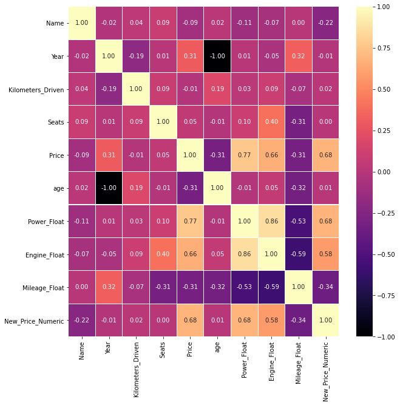

```python
fig,ax = plt.subplots(figsize=(10, 10))
sns.heatmap(df.corr(), ax=ax, annot=True, linewidths=0.05, fmt= '.2f',cmap="magma") # the color intensity is based on
plt.show()
#sns.heatmap(df.corr(), annot = True)
```

1.Year and age have negative correlation.

```python
df.shape
```

```
(7253, 15)
```

```python
df
```

| S.No. | Name | Location | Year | Kilometers_Driven | Fuel_Type | Transmission | Owner_Type | Seats | Price | brand | age | Power_Float | Engine_Float | Mileage_Float | New_Price_Numeric |
| --- | --- | --- | --- | --- | --- | --- | --- | --- | --- | --- | --- | --- | --- | --- | --- |
| 0 | 1797 | Mumbai | 2010 | 72000 | CNG | Manual | First | 5.0 | 1.75 | Maruti | 11 | 58.16 | 998.0 | 26.60 | NaN |
| 1 | 498 | Pune | 2015 | 41000 | Diesel | Manual | First | 5.0 | 12.50 | Hyundai | 6 | 126.20 | 1582.0 | 19.67 | NaN |
| 2 | 993 | Chennai | 2011 | 46000 | Petrol | Manual | First | 5.0 | 4.50 | Honda | 10 | 88.70 | 1199.0 | 18.20 | 861000.0 |
| 3 | 676 | Chennai | 2012 | 87000 | Diesel | Manual | First | 7.0 | 6.00 | Maruti | 9 | 88.76 | 1248.0 | 20.77 | NaN |
| 4 | 105 | Coimbatore | 2013 | 40670 | Diesel | Automatic | Second | 5.0 | 17.74 | Audi | 8 | 140.80 | 1968.0 | 15.20 | NaN |
| ... | ... | ... | ... | ... | ... | ... | ... | ... | ... | ... | ... | ... | ... | ... | ... |
| 7248 | 1701 | Hyderabad | 2011 | 89411 | Diesel | Manual | First | 5.0 | NaN | Volkswagen | 10 | 103.60 | 1598.0 | 20.54 | NaN |
| 7249 | 1252 | Mumbai | 2015 | 59000 | Petrol | Automatic | First | 5.0 | NaN | Volkswagen | 6 | 103.60 | 1197.0 | 17.21 | NaN |
| 7250 | 1101 | Kolkata | 2012 | 28000 | Diesel | Manual | First | 5.0 | NaN | Nissan | 9 | 63.10 | 1461.0 | 23.08 | NaN |
| 7251 | 1252 | Pune | 2013 | 52262 | Petrol | Automatic | Third | 5.0 | NaN | Volkswagen | 8 | 103.60 | 1197.0 | 17.20 | NaN |
| 7252 | 551 | Kochi | 2014 | 72443 | Diesel | Automatic | First | 5.0 | NaN | Mercedes-Benz | 7 | 170.00 | 2148.0 | 10.00 | NaN |

7253 rows × 15 columns

# car's age

```python
df.age.unique()
```

```
array([11,  6, 10,  9,  8,  5,  3,  7,  4, 14, 12, 13,  2, 15, 16, 17, 19,
       21, 18, 22, 20, 23, 25])
```

```python
df.info()
```

```
<class 'pandas.core.frame.DataFrame'>
Int64Index: 7253 entries, 0 to 7252
Data columns (total 15 columns):
 #   Column             Non-Null Count  Dtype
---  ------             --------------  -----
 0   Name               7253 non-null   int64
 1   Location           7253 non-null   object
 2   Year               7253 non-null   int64
 3   Kilometers_Driven  7253 non-null   int64
 4   Fuel_Type          7253 non-null   object
 5   Transmission       7253 non-null   object
 6   Owner_Type         7253 non-null   object
 7   Seats              7200 non-null   float64
 8   Price              6019 non-null   float64
 9   brand              7253 non-null   object
 10  age                7253 non-null   int64
 11  Power_Float        7078 non-null   float64
 12  Engine_Float       7207 non-null   float64
 13  Mileage_Float      7251 non-null   float64
 14  New_Price_Numeric  1006 non-null   float64
dtypes: float64(6), int64(4), object(5)
memory usage: 1.2+ MB
```

# Fill missing value

```python
df['Mileage_Float']=df['Mileage_Float'].fillna(df['Mileage_Float'].median())
df['Engine_Float']=df['Engine_Float'].fillna(df['Engine_Float'].median())
df['Power_Float']=df['Power_Float'].fillna(df['Power_Float'].median())
df['New_Price_Numeric']=df['New_Price_Numeric'].fillna(df['New_Price_Numeric'].median())
df['Kilometers_Driven']=df['Kilometers_Driven'].fillna(df['Kilometers_Driven'].median())
```

```python
df['Price'] = df['Price'].replace(np.nan, 0)
df['Seats'] = df['Seats'].replace(np.nan,0)
```

```python
df.isnull().sum()
```

```
Name                 0
Location             0
Year                 0
Kilometers_Driven    0
Fuel_Type            0
Transmission         0
Owner_Type           0
Seats                0
Price                0
brand                0
age                  0
Power_Float          0
Engine_Float         0
Mileage_Float        0
New_Price_Numeric    0
dtype: int64
```

There is no null value in the columns.

```python
df.info()
```

```
<class 'pandas.core.frame.DataFrame'>
Int64Index: 7253 entries, 0 to 7252
Data columns (total 15 columns):
 #   Column             Non-Null Count  Dtype
---  ------             --------------  -----
 0   Name               7253 non-null   int64
 1   Location           7253 non-null   object
 2   Year               7253 non-null   int64
 3   Kilometers_Driven  7253 non-null   int64
 4   Fuel_Type          7253 non-null   object
 5   Transmission       7253 non-null   object
 6   Owner_Type         7253 non-null   object
 7   Seats              7253 non-null   float64
 8   Price              7253 non-null   float64
 9   brand              7253 non-null   object
 10  age                7253 non-null   int64
 11  Power_Float        7253 non-null   float64
 12  Engine_Float       7253 non-null   float64
 13  Mileage_Float      7253 non-null   float64
 14  New_Price_Numeric  7253 non-null   float64
dtypes: float64(6), int64(4), object(5)
memory usage: 1.2+ MB
```

```python
df
```

| S.No. | Name | Location | Year | Kilometers_Driven | Fuel_Type | Transmission | Owner_Type | Seats | Price | brand | age | Power_Float | Engine_Float | Mileage_Float | New_Price_Numeric |
| --- | --- | --- | --- | --- | --- | --- | --- | --- | --- | --- | --- | --- | --- | --- | --- |
| 0 | 1797 | Mumbai | 2010 | 72000 | CNG | Manual | First | 5.0 | 1.75 | Maruti | 11 | 58.16 | 998.0 | 26.60 | 1127000.0 |
| 1 | 498 | Pune | 2015 | 41000 | Diesel | Manual | First | 5.0 | 12.50 | Hyundai | 6 | 126.20 | 1582.0 | 19.67 | 1127000.0 |
| 2 | 993 | Chennai | 2011 | 46000 | Petrol | Manual | First | 5.0 | 4.50 | Honda | 10 | 88.70 | 1199.0 | 18.20 | 861000.0 |
| 3 | 676 | Chennai | 2012 | 87000 | Diesel | Manual | First | 7.0 | 6.00 | Maruti | 9 | 88.76 | 1248.0 | 20.77 | 1127000.0 |
| 4 | 105 | Coimbatore | 2013 | 40670 | Diesel | Automatic | Second | 5.0 | 17.74 | Audi | 8 | 140.80 | 1968.0 | 15.20 | 1127000.0 |
| ... | ... | ... | ... | ... | ... | ... | ... | ... | ... | ... | ... | ... | ... | ... | ... |
| 7248 | 1701 | Hyderabad | 2011 | 89411 | Diesel | Manual | First | 5.0 | 0.00 | Volkswagen | 10 | 103.60 | 1598.0 | 20.54 | 1127000.0 |
| 7249 | 1252 | Mumbai | 2015 | 59000 | Petrol | Automatic | First | 5.0 | 0.00 | Volkswagen | 6 | 103.60 | 1197.0 | 17.21 | 1127000.0 |
| 7250 | 1101 | Kolkata | 2012 | 28000 | Diesel | Manual | First | 5.0 | 0.00 | Nissan | 9 | 63.10 | 1461.0 | 23.08 | 1127000.0 |
| 7251 | 1252 | Pune | 2013 | 52262 | Petrol | Automatic | Third | 5.0 | 0.00 | Volkswagen | 8 | 103.60 | 1197.0 | 17.20 | 1127000.0 |
| 7252 | 551 | Kochi | 2014 | 72443 | Diesel | Automatic | First | 5.0 | 0.00 | Mercedes-Benz | 7 | 170.00 | 2148.0 | 10.00 | 1127000.0 |

7253 rows × 15 columns

# univariate analysis

```python
def hist_box(value, figsize=(15,10), bins = None):
    f2, (ax_box2, ax_hist2) = plt.subplots(nrows = 2,
                                           sharex = True,
                                           gridspec_kw = {"height_ratios": (.25, .75)},
                                           figsize = figsize
                                           )
    sns.boxplot(value, ax=ax_box2, showmeans=True, color='violet')
    sns.distplot(value, kde=F, ax=ax_hist2, bins=bins,palette="winter") if bins else sns.distplot(value, kde=False, ax=ax_hist2)
    ax_hist2.axvline(np.mean(value), color='green', linestyle='--')
    ax_hist2.axvline(np.median(value), color='black', linestyle='-')
```

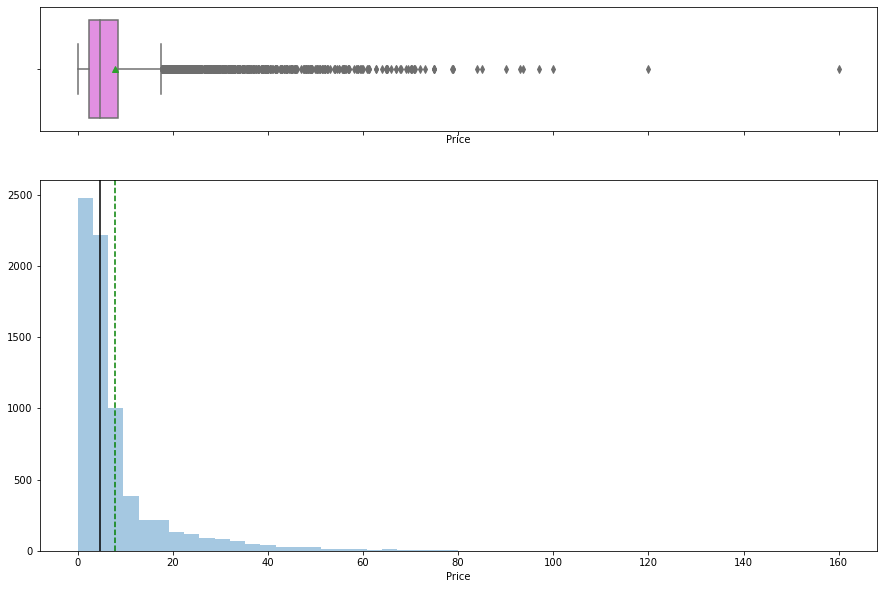

```python
hist_box(df["Price"])
```

# Observation

1.seems price is skewed right  
2.many outliers

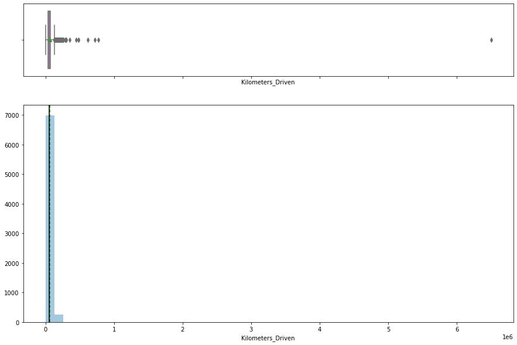

```python
hist_box(df["Kilometers_Driven"])
```

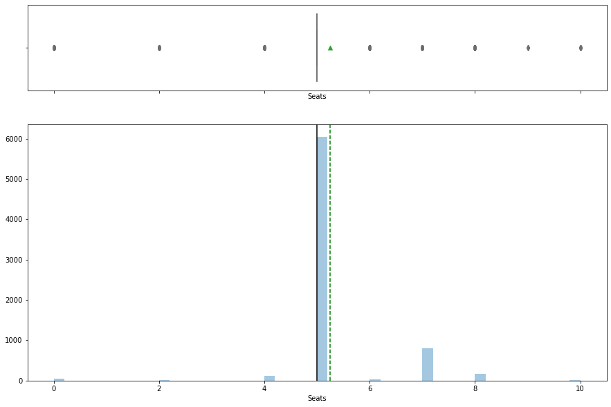

```python
hist_box(df["Seats"])
```

# Observation

1.most of the cars have 5 seats.

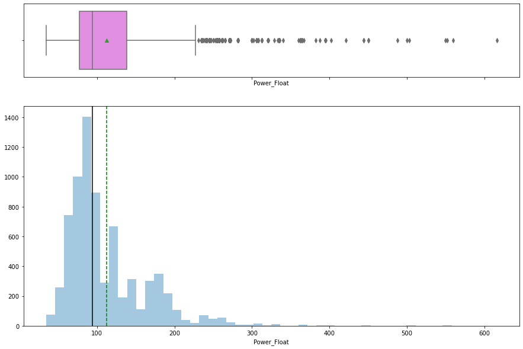

```python
hist_box(df["Power_Float"])
```

# Observation

1.mean of the power is 110bhp approximately.

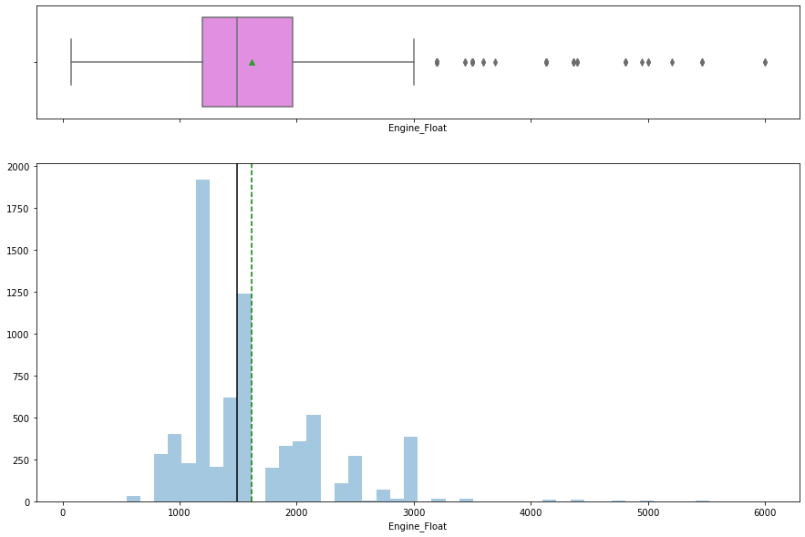

```python
hist_box(df["Engine_Float"])
```

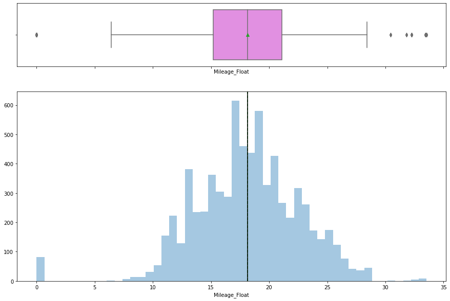

```python
hist_box(df["Mileage_Float"])
```

# Observation

1.Mileage is normalily distributed.

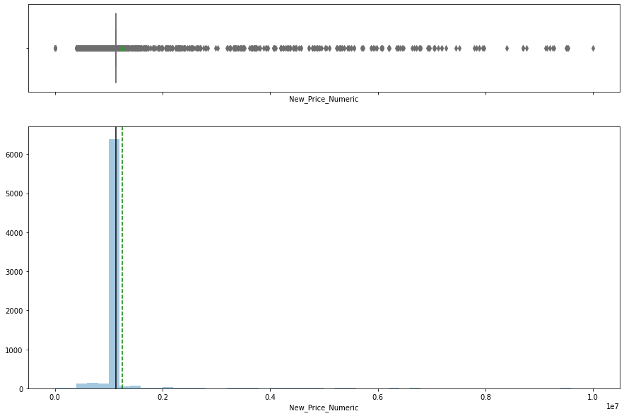

```python
hist_box(df["New_Price_Numeric"])
```

# Observation

1.new price have many outliers.  
2.new price is right skewed

```python
def perc_on_bar(plot, feature):

    total = len(feature)
    for p in ax.patches:
        percentage = '{:.1f}%'.format(100 * p.get_height()/total)
        x = p.get_x() + p.get_width() / 2 - 0.05
        y = p.get_y() + p.get_height()
        ax.annotate(percentage, (x, y), size = 12)
    plt.show()
```

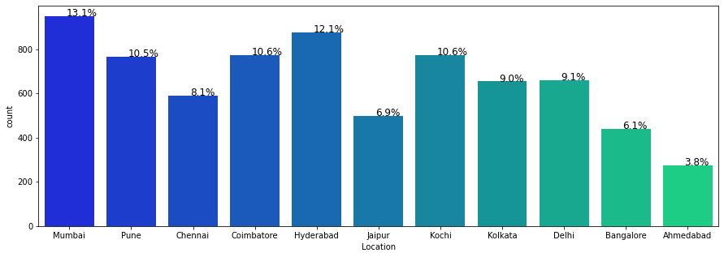

```python
plt.figure(figsize=(15,5))
ax = sns.countplot(df["Location"],palette='winter')
perc_on_bar(ax,df["Location"])
```

1.Mumbai is the place of being sold or is available for purchase  
2.Ahmedabad have 3.8% of the sold or available cars.

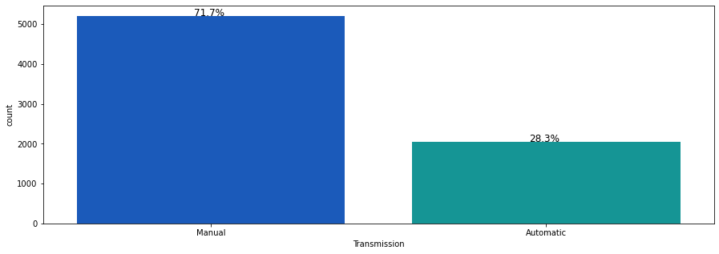

```python
plt.figure(figsize=(15,5))
ax = sns.countplot(df["Transmission"],palette='winter')
perc_on_bar(ax,df["Transmission"])
```

1.majority of the cars are manual.

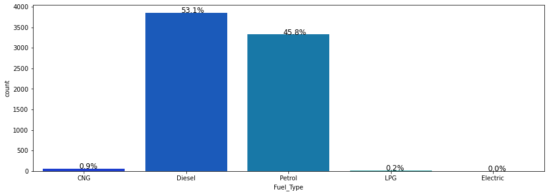

```python
plt.figure(figsize=(15,5))
ax = sns.countplot(df["Fuel_Type"],palette='winter')
perc_on_bar(ax,df["Fuel_Type"])
```

1.More than 90% of the cars are diesel and petrol cars.

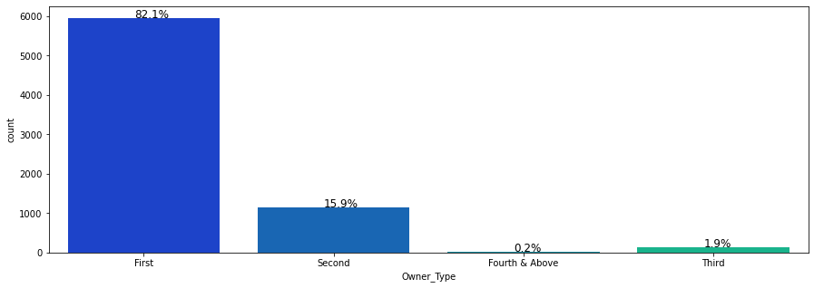

```python
plt.figure(figsize=(15,5))
ax = sns.countplot(df["Owner_Type"],palette='winter')
perc_on_bar(ax,df["Owner_Type"])
```

1.82.1 % of the cars are first hand cars.

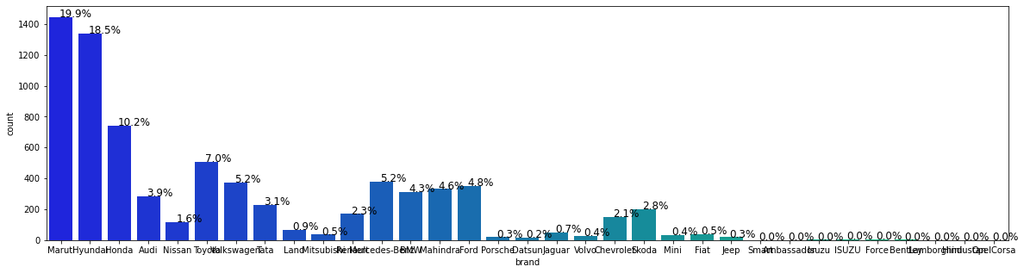

```python
plt.figure(figsize=(20,5))
ax = sns.countplot(df["brand"],palette='winter')
perc_on_bar(ax,df["brand"])
```

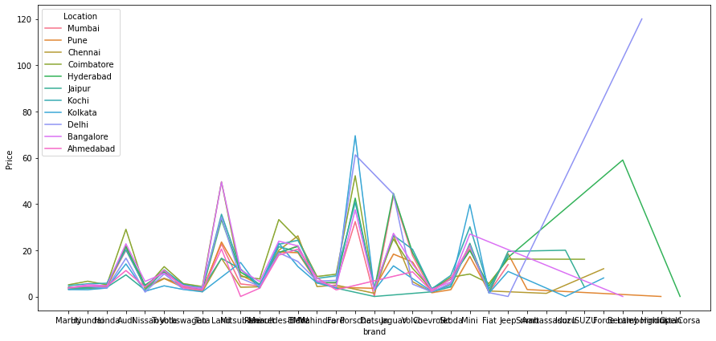

```python
plt.figure(figsize=(15,7))
sns.lineplot(y='Price', x='brand',hue='Location',ci=0,
             data=df);
```

1.In all the locations maruthi and hyundai resale cars prices are less.  
2.People prefer to buy low cost cars.

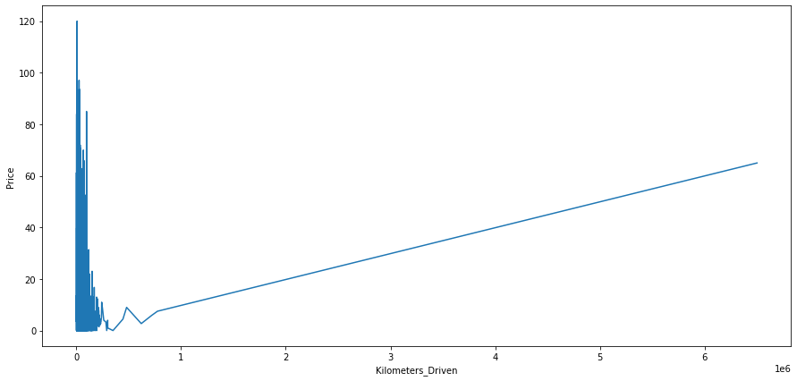

```python
plt.figure(figsize=(15,7))
sns.lineplot(y='Price', x='Kilometers_Driven',ci=0,
             data=df);
```

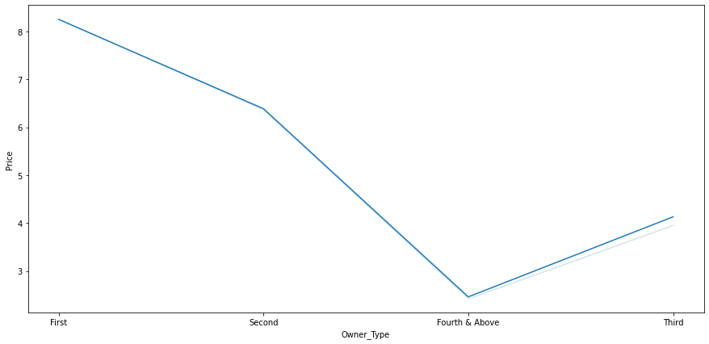

```python
plt.figure(figsize=(15,7))
sns.lineplot(y='Price', x='Owner_Type',ci=0,
             data=df);
```

1.Owner type changes cars price.

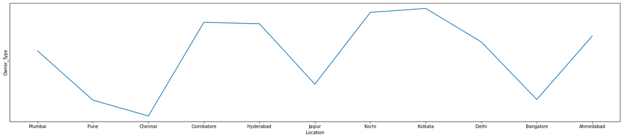

```python
plt.figure(figsize=(25,5))
sns.lineplot(x='Location', y='Owner_Type',ci=0,
             data=df);
```

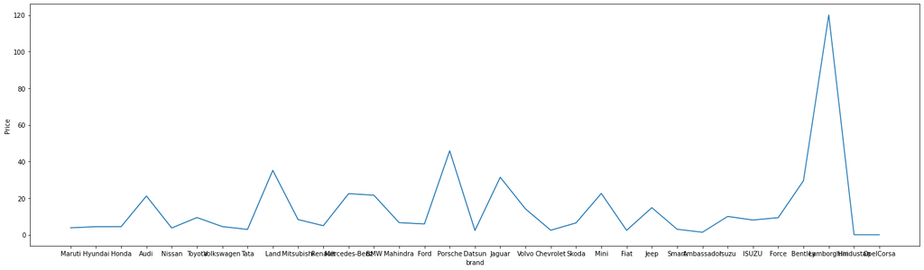

```python
plt.figure(figsize=(25,7))
sns.lineplot(y='Price', x='brand',ci=0,
             data=df);
```

1.luxury cars are costly.

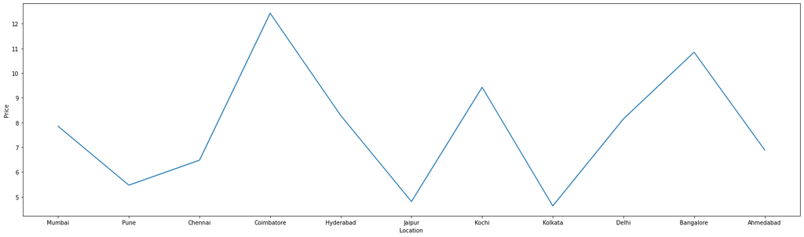

```python
plt.figure(figsize=(25,7))
sns.lineplot(y='Price', x='Location',ci=0,
             data=df);
```

1.Cars price are less in pune,jaipur,kolkata.  
2.But based on the graph we can not conclude that in the aboue mentioned locations prices are less.  
3.On the other hand location which shows high price in the location,luxury cars may sell more.

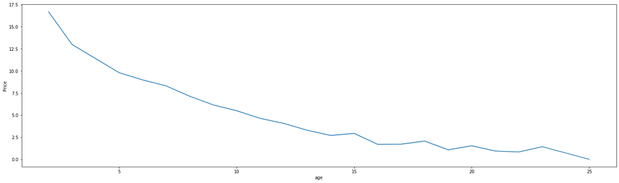

```python
plt.figure(figsize=(25,7))
sns.lineplot(y='Price', x='age',ci=0,
             data=df);
```

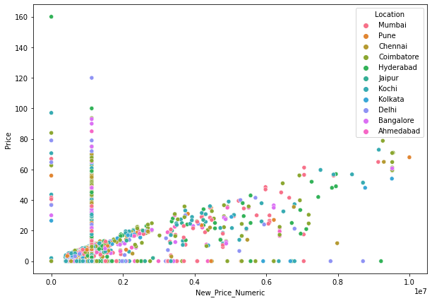

```python
plt.figure(figsize=(10,7));
sns.scatterplot(y="Price", x="New_Price_Numeric",hue="Location",data=df);
```

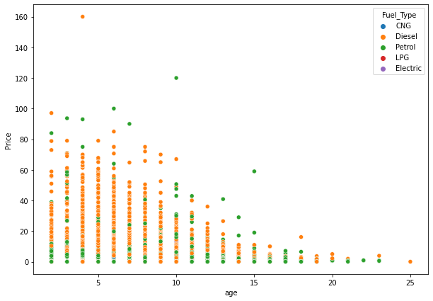

```python
plt.figure(figsize=(10,7));
sns.scatterplot(y="Price", x="age",hue="Fuel_Type",data=df);
```

1.diesel and petrol cars are most salable.  
2.People prefer to buy less age cars.

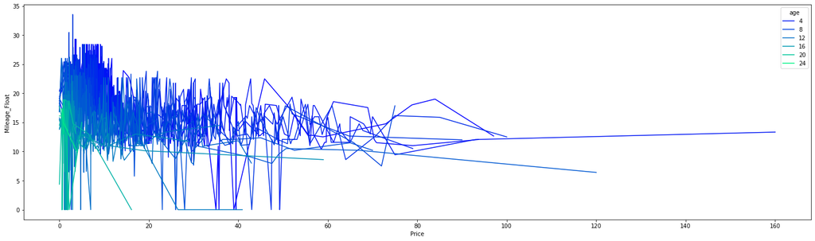

```python
plt.figure(figsize=(25,7))
sns.lineplot(y='Mileage_Float', x='Price',hue='age',palette = 'winter',ci=0,
             data=df);
```

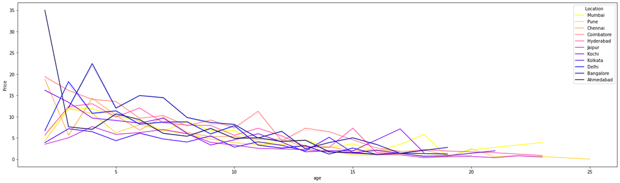

```python
plt.figure(figsize=(25,7))
sns.lineplot(y='Price', x='age',hue='Location',palette="gnuplot2_r",ci=0,
             data=df);
```